# Homework Sheet 2 – Wrangle, Summarize, Visualize – Excercises

39

Due: Wednesday, November 18 by 11:59 CET

# Instructions

- If you need help, take a look at the suggested readings in the lecture, make use of the [cheat sheets](https://rstudio.com/resources/cheatsheets/) and the help possibility in R
- Make sure you have R and RStudio installed. If you are an advanced user and aren’t using RStudio, make sure you have everything installed in order to ‘knit’ the HTML output.
- Create an Rmd-file with your group number (equivalent to StudIP group) in the ‘author’ heading and answer the following questions.
- When all answers are ready, ‘Knit’ the document to produce a HTML file.
- Create a ZIP archive called “IDA_HW02-Group-XYZ.zip” (where ‘XYZ’ is *your* group number) containing:
  - an R Markdown file “IDA_HW02-Group-XYZ.Rmd”
  - a knitted HTML document “IDA_HW02-Group-XYZ.html”
  - include the data files ‘WHO.csv’ and ‘BLJM-data-2020.csv’ as well
  - any other files necessary to compile your Rmarkdown to HTML (pictures etc.)
- Upload the ZIP archive on Stud.IP in your group folder before the deadline (see above). You may upload as many times as you like before the deadline, only your final submission will count.

# Exercise 1: Explore your own BLJM data [15 points]

Make sure you obtained the file `BLJM-data-2020.csv` from StudIP. It contains data from the “Bio-Logic Jazz-Metal” experiment, which is also coverd in the web-book. But this data is what *you* have produced by taking part in the voluntary web-experiment. So, let’s go analyze **YOUR** preferences!

## Ex 1.a Global summary statistics [2 points]

Load the file using the code below (the CSV file should be in the same directory as your Rmd file).

```r
data_BLJM <- read_csv("BLJM-data-2020.csv")
data_BLJM
```

```
## # A tibble: 348 x 16
##    submission_id    RT   age comments education endTime experiment_id gender
##            <dbl> <dbl> <dbl> <chr>    <chr>       <dbl>         <dbl> <chr>
##  1          1225  6258    20 <NA>     Graduate… 1.60e12            44 female
##  2          1225  3237    20 <NA>     Graduate… 1.60e12            44 female
##  3          1225  1704    20 <NA>     Graduate… 1.60e12            44 female
##  4          1224  3337    24 <NA>     Graduate… 1.60e12            44 female
##  5          1224  2198    24 <NA>     Graduate… 1.60e12            44 female
##  6          1224  1828    24 <NA>     Graduate… 1.60e12            44 female
##  7          1223 12299    21 <NA>     Graduate… 1.60e12            44 female
##  8          1223  6937    21 <NA>     Graduate… 1.60e12            44 female
##  9          1223  3148    21 <NA>     Graduate… 1.60e12            44 female
## 10          1222  5629    21 <NA>     Graduate… 1.60e12            44 female
## # … with 338 more rows, and 8 more variables: languages <chr>, option1 <chr>,
## #   option2 <chr>, response <chr>, startTime <dbl>, timeSpent <dbl>,
## #   trial_name <chr>, trial_number <dbl>
```

Use R to display the following information:

1. the number of rows in the data set
2. the number of different entries in the column `submission_id` (many different solutions possible, try a combination of `group_by`, `summarize` and `nrow` if you like)
3. the mean `timeSpent`
4. the mean `age` (*Hint:* use the option `mean(.., na.rm=T)` to remove entries with `NA`)

```r
# 1 number of rows
nrow(data_BLJM)
```

```
## [1] 348
```

```r
# 2 I suppose they are asking for total number of subjects
data_BLJM %>%
  group_by(submission_id) %>% #look at column of subject ids
  summarise() %>% #groups duplicates together
  nrow(.)  #counts number of rows
```

```
## [1] 116
```

```r
# 3 mean of variable timeSpent
data_BLJM %>%
  summarise(
    timeSpent_mean = mean(timeSpent)
  )
```

```
## # A tibble: 1 x 1
##   timeSpent_mean
##            <dbl>
## 1           2.54
```

```r
# 4 mean of variable age
data_BLJM %>%
  summarise(
    age_mean = mean(age, na.rm = T)
  )
```

```
## # A tibble: 1 x 1
##   age_mean
##      <dbl>
## 1     22.2
```

## Ex 1.b Grouped summary statistics [2 points]

Use piping to perform the following steps on `data_BLJM`:

1. throw out all rows where the column `gender` has an entry of `NA` (*Hint*: use function `is.na` and Boolean negation);
2. group by `gender`
3. obtain the mean and (unbiased) standard deviation for `age` (exluding `NA`s in both functions (see Ex 1.a))

```r
data_BLJM %>%
  filter(., !is.na(gender)) %>%
  group_by(gender) %>%
  summarise(
    age_mean = mean(age, na.rm = T),
    stddev_age = sd(age, na.rm = T),
  )
```

```
## # A tibble: 2 x 3
##   gender age_mean stddev_age
##   <chr>     <dbl>      <dbl>
## 1 female     21.8       2.87
## 2 male       22.6       3.58
```

## Ex 1.c Preprocessing [2 points]

We will use the code from [Appendix D of the web-book](https://michael-franke.github.io/intro-data-analysis/app-93-data-sets-BLJM.html) to process the data for more convenient analysis. Insert short but insightful comments in the code below:

```r
data_BLJM_processed <-
  data_BLJM %>%
  # creating column 'condition' by building entries from the first letter
  # of option1 and option2 respectively, for each subject
  mutate(
    condition = str_c(str_sub(option2, 1, 1), str_sub(option1, 1, 1))
  ) %>%
  # only keep these columns in variable data_BLJM
  select(submission_id, condition, response)

data_BLJM_processed
```

```
## # A tibble: 348 x 3
##    submission_id condition response
##            <dbl> <chr>     <chr>
##  1          1225 JM        Metal
##  2          1225 LB        Logic
##  3          1225 BM        Beach
##  4          1224 BM        Beach
##  5          1224 JM        Jazz
##  6          1224 LB        Biology
##  7          1223 BM        Beach
##  8          1223 JM        Jazz
##  9          1223 LB        Biology
## 10          1222 JM        Jazz
## # … with 338 more rows
```

## Ex 1.d Obtaining counts for all three choices [2 points]

Produce a tibble with 8 rows which contains the following tidy data for later processing:

1. a character column `JM` which contains entries for Jazz vs Metal
2. a character column `LB` which contains entries for Biology vs Logic
3. a character column `BM` which contains entries for Beach vs Mountain
4. a column that contains the number of times the triple of choices in each row occurred in the data

(*Hint*: You can recycle code from the web-book, but you need to find it (and possibly tweak it).)

```r
data_BLJM_conditions <- data_BLJM_processed %>%
    pivot_wider(names_from =condition, values_from = response) %>%
    dplyr::count(JM, LB, BM)

data_BLJM_conditions
```

```
## # A tibble: 8 x 4
##   JM    LB      BM            n
##   <chr> <chr>   <chr>     <int>
## 1 Jazz  Biology Beach        20
## 2 Jazz  Biology Mountains    22
## 3 Jazz  Logic   Beach        25
## 4 Jazz  Logic   Mountains    25
## 5 Metal Biology Beach         8
## 6 Metal Biology Mountains     5
## 7 Metal Logic   Beach         5
## 8 Metal Logic   Mountains     6
```

## Ex 1.e Obtaining counts for music+subject choices [2 points]

Produce a similar table as for the previous exercise but only for the `JM` and `LB` columns.

```r
data_BLJM_conditions_select <- data_BLJM_processed %>%
   pivot_wider(names_from =condition, values_from = response) %>% #
   select(-BM) %>%
   dplyr::count(JM, LB)

data_BLJM_conditions_select
```

```
## # A tibble: 4 x 3
##   JM    LB          n
##   <chr> <chr>   <int>
## 1 Jazz  Biology    42
## 2 Jazz  Logic      50
## 3 Metal Biology    13
## 4 Metal Logic      11
```

## Ex 1.f Plot the music+subject choices [2 points]

Create a plot for the current data set similar to that of Figure 5.1 from the web-book. Comment your code exetensivly, explaining each relevant step as if you were trying to teach somebody R and ggplot.

(*Hint*: you can recycle code from the web-book, but you need to find it.)

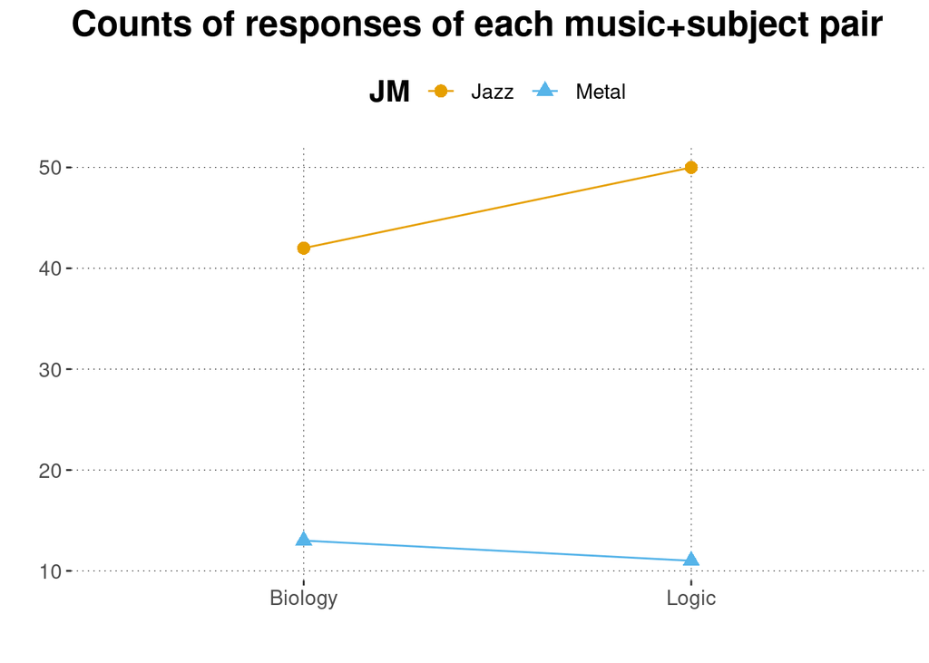

```r
data_BLJM_conditions_select %>%
  ggplot(aes(
    # define x ...
    x = LB,
    # ... and y axis
    y = n,
    # use different colors for Jazz and Metal
    color = JM,
    # use different shapes for Jazz and Metal
    shape = JM,
    # we want to create points / lines for Jazz and Metal separately, not together
    group = JM
   )
  ) +
  # plot the points with size 3
  geom_point(size = 3) +
  # create respective lines for Jazz and Metal
  geom_line() +
  # add labels describing plot
  labs(
    title = "Counts of responses of each music+subject pair",
    x = "",
    y = ""
  )
```

## Ex 1.g Interpret the plot [3 points]

Argue, if you can, that the lecturer’s conjecture is true: students who like metal also prefer logic, and vice versa. Or, if you must, argue that the the data does not provide (visual) evidence for the lecturer’s conjecture. (Make your answer short; at most four concise sentences, please!)

## Answer

People who chose Logic chose more often Jazz than Metal. People who chose Metal chose more often Biology than Logic. As such, the data provides counter-evidence to the lecturer’s conjecture.

# Exercise 2: Musings about modes [5 points]

Suppose we have a vector of metric data points, stemming from measurements of weight of around ten thousand seagulls. The weight has been determined up to the yoctogram level. (Just imagine that this was actually possible!) Why would it probably not make much good sense to consider the mode of this vector as an indicator of central tendency of these measurements?

## Answer

As mentioned in the web book, the mode “is the unique value that occurred most frequently in the data”. Considering that we are measuring weights on a yoctogram level, even with data of ten thousand seagulls, it’s highly likely that no weight measurement will occur twice (in which case, there would be no mode) or that maybe a very small number of (like max. 10) seagulls have the same weight (let’s call that weight x) up to the yoctogram level. ( In the latter case, the mode is not a good measure of tendency since while the weight x would be the most frequent one, it is likely that just by random chance, x happened to be the mode in our specific data set, while it could have just as well been a (completely) different value if we sampled another 10000 seagull weights.

# Exercise 3: Exploring two-dimensional metric measurements [15 points]

We are now going to practice plotting and analyzing metric data from more than one variable. To do this, we first load the WHO data set with the code below.

```r
data_WHO <- read_csv('WHO.csv')
```

The WHO data set has a number of health-related measurements for most of the world’s nations, grouped by region. It is useful for you if you try to explore the data set on your own, just to see what is there. (*Hint:* try `View(data_WHO` in RStudio).

## Ex 3.a Calculate a correlation score [2 points]

Use R’s built-in function `cor` to compute the Bravais-Pearson correlation between the variables `FertilityRate` and `LifeExpectancy`. Notice that you must first remove all entries in either column with missing data.

```r
fr_and_le <- data_WHO %>%
  # select only FertilityRate and LifeExpectancy
  select(FertilityRate, LifeExpectancy) %>%
  # filter out rows with na values
  filter(!(is.na(FertilityRate) | is.na(LifeExpectancy)))

# compute correlation
cor(fr_and_le)
```

```
##                FertilityRate LifeExpectancy
## FertilityRate      1.0000000     -0.8398395
## LifeExpectancy    -0.8398395      1.0000000
```

## Ex 3.b Interpret a correlation score [3 points]

Interpret this numerical result. Your answer be something like the following (but hopefully much better): “There appears to be a positive correlation between $X$ and $Y$ suggesting that as $X$ increases $Y$ will decrease. This is proof that $X$ is a causally related to $Y$, in fact that $Y$ is the cause of $X$.”

#### Answer

There appears to be a negative correlation between FertilityRate and LifeExpectancy. That is, with larger FertilityRate values, LifeExpectanty values become lower and vice versa.  
However, this does not imply that the two are causally related.

## Ex 3.c Compute correlation scores for each region [2 points]

Use R’s built-in function `cor` to compute the Bravais-Pearson correlation between the variables `FertilityRate` and `LifeExpectancy` seperately for each region. Use `group_by` and remember to remove missing values. Store the resulting tibble in a variable called `correlation_WHO` because we will use it later on.

```r
correlation_WHO <- data_WHO %>%
  # only select relevant variables
  select(Region, FertilityRate, LifeExpectancy) %>%
  # filter out rows with na values
  filter(!(is.na(FertilityRate) | is.na(LifeExpectancy))) %>%
  group_by(Region) %>%
  # add column for correlations
  mutate(correlation = cor(FertilityRate, LifeExpectancy)) %>%
  # remove duplicate region rows
  distinct(., Region, .keep_all = T)

correlation_WHO
```

```
## # A tibble: 6 x 4
## # Groups:   Region [6]
##   Region                FertilityRate LifeExpectancy correlation
##   <chr>                         <dbl>          <dbl>       <dbl>
## 1 Eastern Mediterranean          5.4              60      -0.846
## 2 Europe                         1.75             74      -0.320
## 3 Africa                         2.83             73      -0.632
## 4 Americas                       2.12             75      -0.629
## 5 Western Pacific                1.89             82      -0.732
## 6 South-East Asia                2.24             70      -0.456
```

## Ex 3.d Make a scatter plot [3 points]

Create a scatterplot (using `geom_point`) showing `FertilityRate` on the $x$-axis and `LifeExpectancy` on the $y$-axis. Add a linear regression line, using `geom_smooth`. (*Hint*: See Section 6.3.3 of the web-book). For good sports, check the documentation of `geom_smooth` to find an option that suppresses the gray area around the regression line (which is a confidence interval; a concept we will learn about later in the course). Finally, adjust the axis labels, so as not to show CamelCaseLabels but “Nice labels with spaces”.

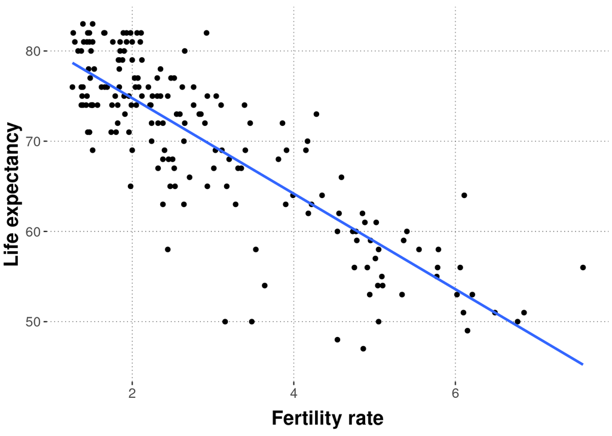

```r
data_WHO %>%
  ggplot(
    #map "FertilityRate" onto x-axis
    mapping = aes(x = FertilityRate,
    #map "LifeExpectancy" onto y-axis
                  y = LifeExpectancy))+
    #add a scatter plot
  geom_point()+
    #add a linear regression line
  geom_smooth(method = "lm",
    #remove the confidence interval
              se = FALSE)+
    #change axis labes
labs(x = 'Fertility rate', y = 'Life expectancy')
```

## Ex 3.e Make a scatter plot facetted by region [2 points]

Use `facet_wrap` to make six nicely arranged scatter plots, one for each level of `Region`, of `FertilityRate` against `LifeExpectancy` (as before: with linear regression lines w/o confidence intervals and nice axis labels). Make sure that each facet has its own range of values shown for the $x$- and $y$-axis, using the `scales` option of `facet_wrap`.

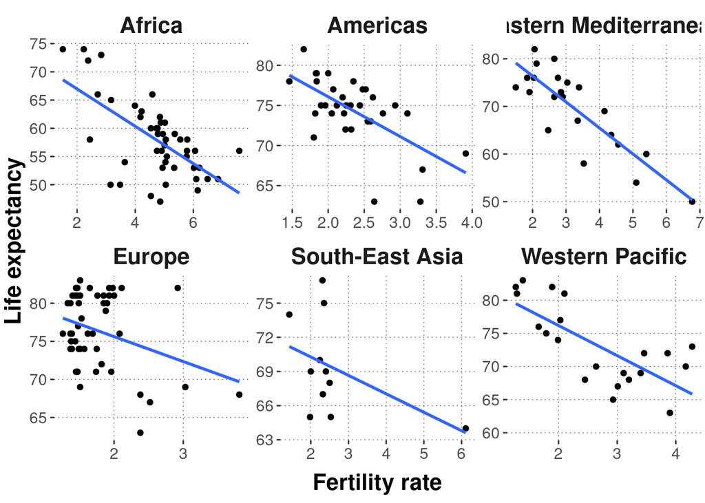

```r
facet <- data_WHO %>%
  ggplot(mapping = aes(x = FertilityRate, y = LifeExpectancy))+
  geom_point()+
  geom_smooth(method = "lm", se = FALSE)+
labs(x = 'Fertility rate', y = 'Life expectancy')+
  #arrange scatter plots one for each level of 'Region'
  facet_wrap(~Region,
  #make each facet have its own range of values(make them free in one dimension)
             scales = "free")
facet
```

## Ex 3.f Add labels to each facet [3 points]

(*Caveat:* This exercise might be more challenging than the others.)

Add the information stored in `correlation_WHO` from Ex. 3.f to each facet using `geom_text`. The following code will help you.

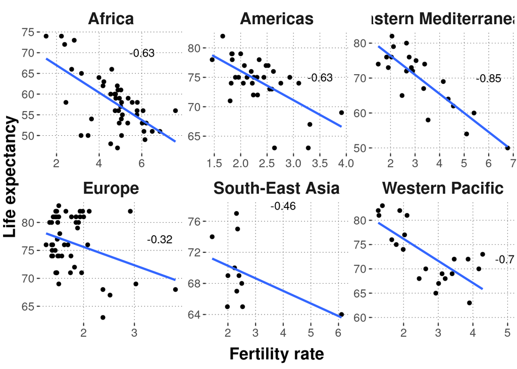

```r
correlation_WHO <- ungroup(correlation_WHO)

correlation_WHO <-
  correlation_WHO %>%
  mutate(
    x = c(6, 3.5, 6, 3.5, 5, 4),
    y = c(70, 77, 70, 75, 72, 78),
    correlation = round(correlation, 2)
  )

facet+
  geom_text(data = correlation_WHO, aes(x = x, y = y, label = correlation))
```